# FDSeries: Computing Functional Diversity over Time in R

### Function 8 `FD_nullPlot()`

Finally, a useful tool is to visualise the empirical trajectory in the empirical functional diversity estimates in contrast with the obtained by the null models and randomisation of the abundance. This function plots the summary data returned by the function `FD_nullSummary` and the data returned by `FD_metrics` and `FD_Rao`. This function can be called directly from `FD_nullcom` and from `FD_nullsummary`.  
The arguments of the function are:

- `d.rao`: a *dataframe* obtained after running the function `FD_nullSummary`.
- `d.FD`: a *dataframe* obtained after running the function `FD_nullSummary`.
- `sumRao`: *dataframe*. Empirical estimates obtained after running the function `FD_Rao`.
- `sumFD`: *dataframe*. Empirical estimates obtained after running the function `FD_metrics`.
- `plotRao`: `TRUE` or `FALSE`. Do wou want to plot the Rao’s, Simpson’s and functional redundancy estimates with the null models. Default `TRUE`.
- `saveRao`: `TRUE` or `FALSE`. Do wou want to save the Rao’s, Simpson’s and functional redundancy estimates with the null models. Default `TRUE`.
- `plotFRic`: `TRUE` or `FALSE`. Do wou want to plot the functional richness (`FRic`) estimates with the null models? Default `TRUE`.
- `saveFRic`: `TRUE` or `FALSE`. Do wou want to save the Rao’s, Simpson’s and functional redundancy estimates with the null models. Default `TRUE`.

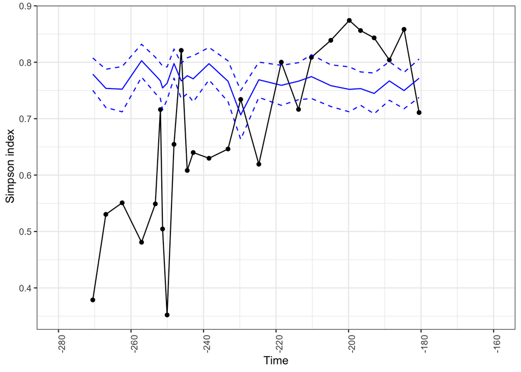

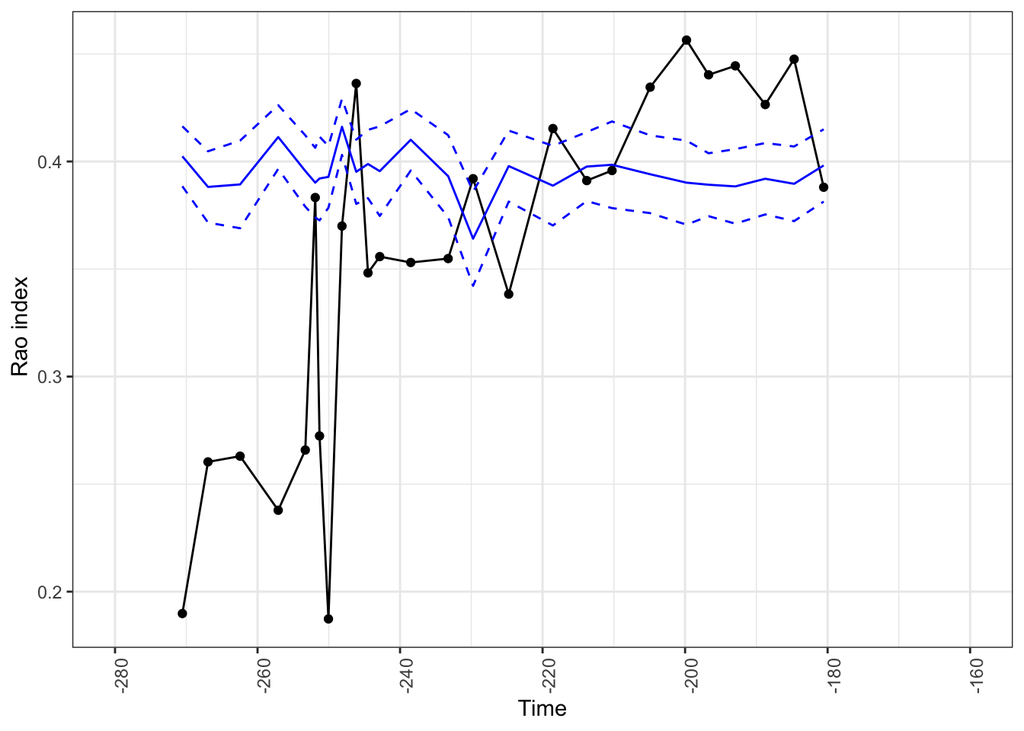

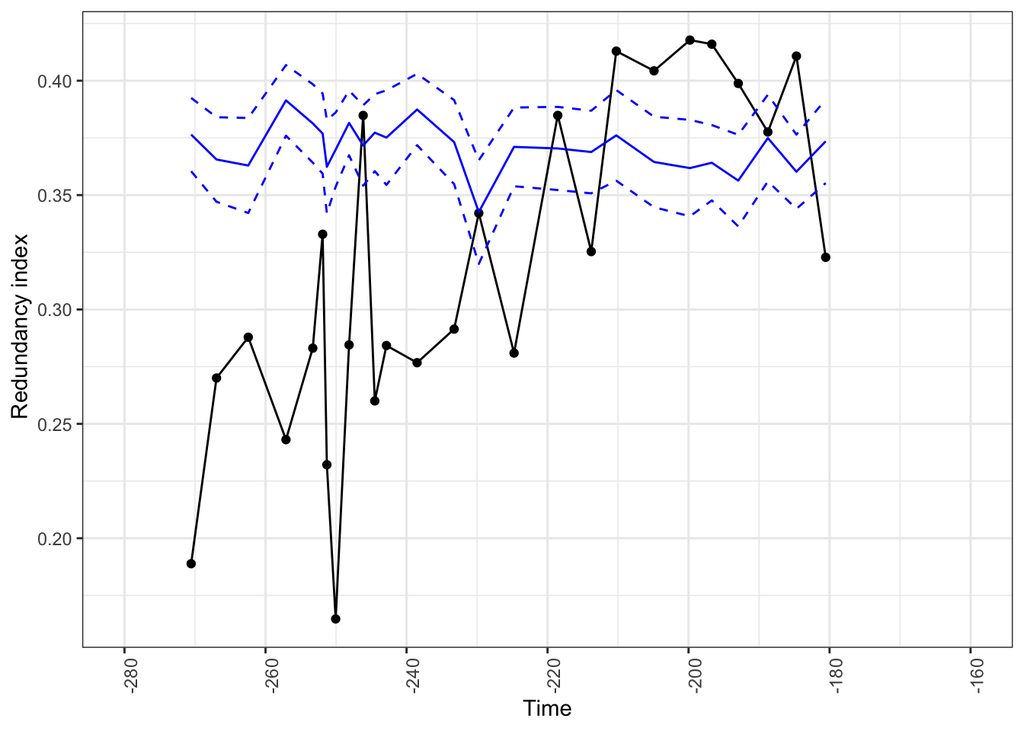

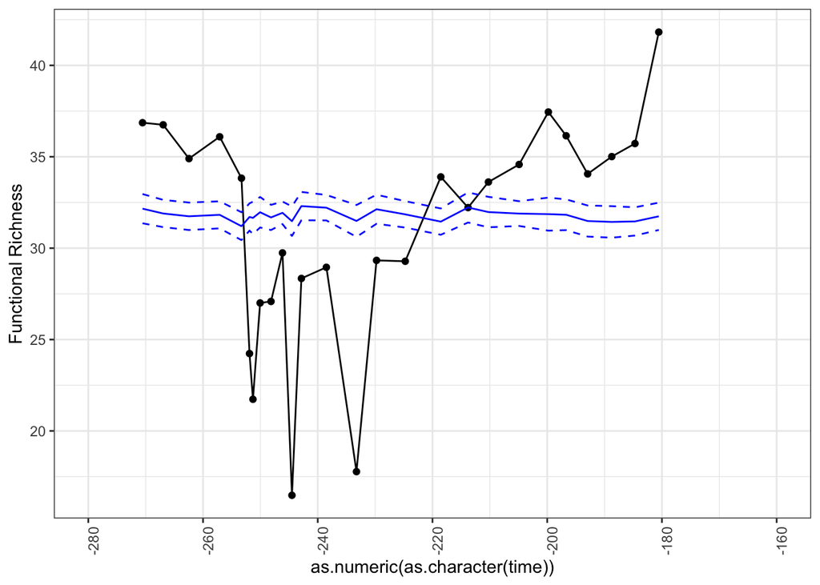

```r
FD_nullPlot(d.rao = summarynullRao, d.FD = summarynullFD, sumRao = RaoSummary, sumFD = FDSummary, plotRao = TRUE, saveRao = FALSE, plotFRic = TRUE, saveFRic = FALSE)
```

The function plot a named list with each plot made with `ggplot2` and prints in the plot window (if `plotRao` and/or `plotFRic` are `TRUE`); and will save the corresponding plots in `png` format in the `wd`.

## Literature cited

Rao, C. Radhakrishna. 1982. “Diversity and Dissimilarity Coefficients: A Unified Approach.” *Theoretical Population Biology* 21 (1): 24–43. https://doi.org/10.1016/0040-5809(82)90004-1.

Villéger, Sébastien, Norman W. H. Mason, and David Mouillot. 2008. “New Multidimensional Functional Diversity Indices for a Multifaceted Framework in Functional Ecology.” *Ecology* 89 (8): 2290–2301. https://doi.org/10.1890/07-1206.1.